# A Homework of Biblical Proportions

Yun-Hui Liu

In this HW, we will analyze the text of the bible. The ascii version resides in the file “ascii_bible.txt” on Camino. Use an editor to familiarize yourself with the structure of the file. Then perform the following operations, listed below as questions for you to answer.

## Q1: Read in the file using any R function you like and store each verse in a text array. After which print the top 20 verses. (Remove the top two lines which contain the title.)

```r
library(stringr)
library(stringi)
text<-readLines("ascii_bible.txt")
text1<-text[setdiff(seq(1,length(text)),grep("Book",text))]
empty_lines<-grepl('^\\s*$',text1)
text2<-text1[! empty_lines]
text3<-paste(stri_trim(text2),collapse=" ")

bible<-str_split(text3,"[[:digit:]]{3}:[[:digit:]]{3} ")
bible<-bible[[1]][-1]
print(bible[1:20])
```

```
##  [1] "In the beginning God created the heaven and the earth. "
##  [2] "And the earth was without form, and void; and darkness was upon the face of the deep. And the Spirit of God moved upon the face of the waters. "
##  [3] "And God said, Let there be light: and there was light. "
##  [4] "And God saw the light, that it was good: and God divided the light from the darkness. "
##  [5] "And God called the light Day, and the darkness he called Night. And the evening and the morning were the first day. "
##  [6] "And God said, Let there be a firmament in the midst of the waters, and let it divide the waters from the waters. "
##  [7] "And God made the firmament, and divided the waters which were under the firmament from the waters which were above the firmament: and it was so. "
##  [8] "And God called the firmament Heaven. And the evening and the morning were the second day. "
##  [9] "And God said, Let the waters under the heaven be gathered together unto one place, and let the dry land appear: and it was so. "
## [10] "And God called the dry land Earth; and the gathering together of the waters called he Seas: and God saw that it was good. "
## [11] "And God said, Let the earth bring forth grass, the herb yielding seed, and the fruit tree yielding fruit after his kind, whose seed is in itself, upon the earth: and it was so. "
## [12] "And the earth brought forth grass, and herb yielding seed after his kind, and the tree yielding fruit, whose seed was in itself, after his kind: and God saw that it was good. "
## [13] "And the evening and the morning were the third day. "
## [14] "And God said, Let there be lights in the firmament of the heaven to divide the day from the night; and let them be for signs, and for seasons, and for days, and years: "
## [15] "And let them be for lights in the firmament of the heaven to give light upon the earth: and it was so. "
## [16] "And God made two great lights; the greater light to rule the day, and the lesser light to rule the night: he made the stars also. "
## [17] "And God set them in the firmament of the heaven to give light upon the earth, "
## [18] "And to rule over the day and over the night, and to divide the light from the darkness: and God saw that it was good. "
## [19] "And the evening and the morning were the fourth day. "
## [20] "And God said, Let the waters bring forth abundantly the moving creature that hath life, and fowl that may fly above the earth in the open firmament of heaven. "
```

## Q2: How many verses are there in total?

```r
print(length(bible))
```

```
## [1] 31102
```

## Q3: Each verse has the number “CCC:VVV” where CCC is the chapter number and VVV is the verse number. How many chapters are there?

```r
empty_lines<-grepl('^\\s*$',text)
book1<-text[! empty_lines]
book2<-paste(stri_trim(book1),collapse=" ")
book3<-as.list(str_split(book2,"Book [[:digit:]]{2}"))
book4<-book3[[1]][-1]

sum=0
pattern1="[[:digit:]]{3}:"
for (i in 1:length(book4)) {
  chapters=length(unique(str_extract_all(book4[i],pattern = pattern1)[[1]]))
  sum=sum+chapters
}
print(sum)
```

```
## [1] 1189
```

## Q4: Extract an array for the verse numbers, and also one for the verse text.

```r
pattern2="[[:digit:]]{3}:[[:digit:]]{3}"
versenum<-str_extract_all(book4,pattern=pattern2)
print(versenum[[1]][1:5])
```

```
## [1] "001:001" "001:002" "001:003" "001:004" "001:005"
```

```r
versetext<-bible
print(head(versetext))
```

```
## [1] "In the beginning God created the heaven and the earth. "
## [2] "And the earth was without form, and void; and darkness was upon the face of the deep. And the Spirit of God moved upon the face of the waters. "
## [3] "And God said, Let there be light: and there was light. "
## [4] "And God saw the light, that it was good: and God divided the light from the darkness. "
## [5] "And God called the light Day, and the darkness he called Night. And the evening and the morning were the first day. "
## [6] "And God said, Let there be a firmament in the midst of the waters, and let it divide the waters from the waters. "
```

## Q5: Lower case all text.

```r
bible<-tolower(bible)
```

## Q6: Convert the text of all verses into a Corpus using the **tm** package.

```r
library(tm)
bible_corpus<-Corpus(VectorSource(bible))
#print(bible_corpus)
```

## Q7: Remove all punctuation. Use a corpus function for this. How many unique words are there in the bible?

```r
removepun<-tm_map(bible_corpus,removePunctuation)
tdm1<-TermDocumentMatrix(removepun,control=list(wordLengths = c(1, Inf)))
print(nrow(tdm1))
```

```
## [1] 12689
```

## Q8: Remove all stopwords. Now how many unique terms are there?

```r
removestops<-tm_map(removepun,removeWords,stopwords("english"))
tdm2<-TermDocumentMatrix(removestops,control=list(wordLengths = c(1, Inf)))
print(nrow(tdm2))
```

```
## [1] 12569
```

## Q9: Now stem the text, to remove multiplicity of similar words of the same root.

```r
library(SnowballC)
stemmed<-tm_map(removestops,stemDocument)
print(stemmed)
```

```
## <<SimpleCorpus>>
## Metadata:  corpus specific: 1, document level (indexed): 0
## Content:  documents: 31102
```

## Q10: How many distinct words are there in the bible, after stemming?

```r
tdm3<-TermDocumentMatrix(stemmed,control=list(wordLengths = c(1, Inf)))
print(nrow(tdm3))
```

```
## [1] 9143
```

## Q11: Convert the TDM into a matrix and find the 50 most common words in the bible.

```r
tdm4<-as.matrix(tdm3)
commonwords<-sort(rowSums(tdm4),decreasing=TRUE)
print(names(commonwords[1:50]))
```

```
##  [1] "shall"    "unto"     "lord"     "thou"     "god"      "thi"
##  [7] "said"     "ye"       "will"     "thee"     "son"      "king"
## [13] "upon"     "man"      "day"      "israel"   "say"      "hath"
## [19] "hous"     "peopl"    "came"     "come"     "one"      "hand"
## [25] "children" "also"     "land"     "thing"    "men"      "father"
## [31] "shalt"    "go"       "let"      "even"     "us"       "made"
## [37] "went"     "offer"    "now"      "behold"   "citi"     "saith"
## [43] "word"     "therefor" "everi"    "hast"     "name"     "make"
## [49] "great"    "o"
```

## Q12: Make a wordcloud of the top 100 words in the bible.

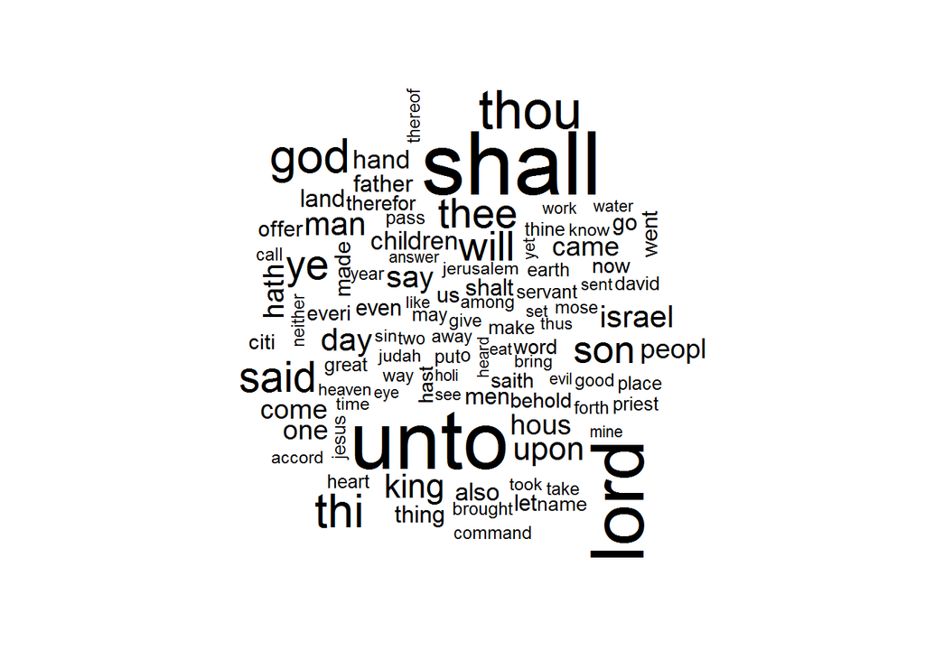

```r
library(wordcloud)
top100<-sort(rowSums(tdm4),decreasing=TRUE)
wordcloud(names(top100[1:100]),top100)
```

## Q13: Mood score the original text of the bible (before stemming)

```r
HIDict = readLines("inqdict.txt")
dict_pos = HIDict[grep("Pos",HIDict)]
poswords = NULL
for (s in dict_pos) {
    s = strsplit(s,"#")[[1]][1]
    poswords = c(poswords,strsplit(s," ")[[1]][1])
}
dict_neg = HIDict[grep("Neg",HIDict)]
negwords = NULL
for (s in dict_neg) {
    s = strsplit(s,"#")[[1]][1]
    negwords = c(negwords,strsplit(s," ")[[1]][1])
}

library(tm)
library(stringr)
# Define read_web_page function
read_web_page = function(url,cstem=0,cstop=0,ccase=0,cpunc=0,cflat=0) {
    text = readLines(url)
    text = text[setdiff(seq(1,length(text)),grep("<",text))]
    text = text[setdiff(seq(1,length(text)),grep(">",text))]
    text = text[setdiff(seq(1,length(text)),grep("]",text))]
    text = text[setdiff(seq(1,length(text)),grep("}",text))]
    text = text[setdiff(seq(1,length(text)),grep("_",text))]
    text = text[setdiff(seq(1,length(text)),grep("\\/",text))]
    ctext = Corpus(VectorSource(text))
    if (cstem==1) { ctext = tm_map(ctext, stemDocument) }
    if (cstop==1) { ctext = tm_map(ctext, removeWords, stopwords("english"))}
    if (cpunc==1) { ctext = tm_map(ctext, removePunctuation) }
    if (ccase==1) { ctext = tm_map(ctext, tolower) }
    if (ccase==2) { ctext = tm_map(ctext, toupper) }
    text = ctext
    #CONVERT FROM CORPUS IF NEEDED
    if (cflat>0) {
        text = NULL
        for (j in 1:length(ctext)) {
            temp = ctext[[j]]$content
            if (temp!="") { text = c(text,temp) }
        }
        text = as.array(text)
    }
    if (cflat==1) {
        text = paste(text,collapse="\n")
        text = str_replace_all(text, "[\r\n]" , " ")
    }
    result = text
}
```

```r
#mood scoring
url<-"ascii_bible.txt"
text<-read_web_page(url,cstem=0,cstop=0,ccase=2,cpunc=1,cflat=0)
text<-str_replace_all(text,"nbsp"," ")
text<-unlist(strsplit(text," "))

posmatch<-match(text,poswords)
numposmatch<-length(posmatch[which(posmatch>0)])
negmatch<-match(text,negwords)
numnegmatch<-length(negmatch[which(negmatch>0)])
print(c(numposmatch,numnegmatch))
```

```
## [1] 50046 33928
```

## Q14: Summarize the bible into less than 500 verses. (Or some fraction of the total number of verses, it’s your choice.) Be super careful here as this may take a long time unless you are clever about it, or find some elegant way to speed things up!

```r
text_summary = function(text, n) {
  m = length(text)  # No of sentences in input
  jaccard = matrix(0,m,m)  #Store match index
  for (i in 1:m) {
    for (j in i:m) {
      a = text[i]; aa = unlist(strsplit(a," "))
      b = text[j]; bb = unlist(strsplit(b," "))
      jaccard[i,j] = length(intersect(aa,bb))/
                          length(union(aa,bb))
      jaccard[j,i] = jaccard[i,j]
    }
  }
  similarity_score = rowSums(jaccard)
  res = sort(similarity_score, index.return=TRUE,
          decreasing=TRUE)
  idx = res$ix[1:n]
  summary = text[idx]
}
```

```r
print("SUMMARY")
```

```
## [1] "SUMMARY"
```

```r
sum<-text_summary(book4,10)
summ<-as.list(NULL)
for(s in 1:length(sum)){
  temp=unlist(strsplit(sum[s],"[[:digit:]{3}:[[:digit:]]{3}"))
  summ[[s]]=text_summary(temp,50)
}
unlist(summ)
```

[output not shown]

[output cut: 485 more lines]

```r
library(topicmodels)
tdm = TermDocumentMatrix(bible_corpus,control=list(minWordLength=1))
dtm=t(tdm)
dtm = dtm[1:500,]

res=LDA(dtm, 3, method="Gibbs", control = list(nstart = 5, seed = list(2003,5,63,100001,765), best = TRUE, burnin = 4000, iter = 2000, thin = 500))
res.terms = as.matrix(terms(res,25))
print(res.terms)
```

```
##       Topic 1  Topic 2 Topic 3
##  [1,] "the"    "unto"  "and"
##  [2,] "that"   "said"  "his"
##  [3,] "was"    "lord"  "they"
##  [4,] "earth"  "shall" "after"
##  [5,] "god"    "thou"  "were"
##  [6,] "all"    "him"   "begat"
##  [7,] "every"  "with"  "years"
##  [8,] "upon"   "for"   "sons"
##  [9,] "from"   "thy"   "their"
## [10,] "them"   "thee"  "hundred"
## [11,] "which"  "will"  "went"
## [12,] "man"    "not"   "lived"
## [13,] "day"    "abram" "came"
## [14,] "waters" "there" "noah"
## [15,] "days"   "had"   "daughters"
## [16,] "let"    "her"   "two"
## [17,] "called" "have"  "into"
## [18,] "made"   "she"   "son"
## [19,] "ark"    "wife"  "one"
## [20,] "face"   "land"  "men"
## [21,] "also"   "when"  "lot"
## [22,] "thing"  "name"  "these"
## [23,] "old"    "shalt" "took"
## [24,] "sodom"  "this"  "brother"
## [25,] "tree"   "but"   "are"
```